# P2

## **Project 2**

Your task: Construct a system to label tasting notes by wine variety

Part 1: Using the training data, construct a classifier that can predict wine variety labels on the basis of review texts. Try out different methods for classification and for preprocessing (don’t forget MWEs and word embeddings) and see what works best. Evaluate your best model using the test data and use an appropriate statistical test to show whether it is significantly better than the MultiomialNB baseline. Describe your best model.

Part 2: Find the words that your model is using to predict labels (either by looking at the model coefficients or by using a tool like LIME). Answer: What aspects of review texts is your model most sensitive to? Is there evidence of overfitting? Anything else noteworthy?

Part 3: In lab 7, we found we could increase the accuracy or F1 score by excluding items that that the model was most uncertain about. Suppose we think accuracy is better than coverage (i.e., it’s okay if we answer “don’t know” when we’re not sure). How many test examples would we have to exclude to achieve better than 0.75 macro-averaged F1 for this task?

Part 4: Another way to improve accuracy is to change the labels. Use a confusion matrix to examine the patterns errors and propose a new labeling scheme. For example, if the model consistently labels “merlot” as “riesling” and vice versa, you might want to create a new label “merlot/riesling”. Is it possible to get better than 0.75 macro-averaged F1 using your classifier trained on a different set of labels?

Submit as one or more HTML files on canvas. Be sure to answer all the questions, in writing!

### **Part-1**

**Importing necessary libraries**

```python
import re

import matplotlib.pyplot as plt
import numpy as np
import pandas as pd
from cytoolz import *
from tqdm.auto import tqdm

tqdm.pandas()
```

**Load and preprocess text**

```python
train = pd.read_parquet("/data/wine-train.parquet")
test = pd.read_parquet("/data/wine-test.parquet")
```

train = train.sample(frac=0.5) test = test.sample(frac=0.5)

```python
train
```

|  | review_text | wine_variant |
| --- | --- | --- |
| 0 | Rich smoky dark cherry nose very intense fruit... | Pinot Noir |
| 1 | Had this at Corton Restaurant in NYC. First of... | Syrah |
| 2 | Nose is very tart, with a layer of sweet fruit... | Pinot Noir |
| 3 | Beautiful golden color. Discrete perfumed nose... | Chardonnay |
| 4 | Please take the time to decant: you will not b... | Pinot Noir |
| ... | ... | ... |
| 130492 | Brought this out at a dinner and it was quite ... | Zinfandel |
| 130493 | Nothing bad to say except that this is so ordi... | Pinot Noir |
| 130494 | Good wine. Dark fruit and buttery oak aromas o... | Cabernet Sauvignon |
| 130495 | AP #8. Medium-deep gold. Mature nose of petrol... | Riesling |
| 130496 | A great nose of lemon, green apple and mineral... | Chardonnay |

130497 rows × 2 columns

**The Data is about Wine Variants and their reviews**

```python
train["wine_variant"].value_counts()
```

```
Pinot Noir            38471
Cabernet Sauvignon    30234
Chardonnay            19443
Syrah                 13704
Riesling               9683
Zinfandel              8327
Merlot                 5522
Sauvignon Blanc        5113
Name: wine_variant, dtype: int64
```

**Seems like the data has more reviews about Pinot Noir, Cabernet Sauvignon, Chardonnay, Syrah than the other wine variants**

**Using spacy to tokenize the review_text of train and test data**

```python
import spacy

nlp = spacy.load(
    "en_core_web_sm",
    exclude=["tagger", "parser", "ner", "lemmatizer", "attribute_ruler"],
)


def tokenize(text):
    doc = nlp.tokenizer(text)
    return [t.norm_ for t in doc if not (t.is_space or t.is_punct or t.like_num)]
```

```python
pd.set_option("display.max_colwidth", 1000)
```

```python
train["tokens"] = train["review_text"].progress_apply(tokenize)
test["tokens"] = test["review_text"].progress_apply(tokenize)
```

**Tokenization completed**

```python
train["tokens"]
```

```
0                                                                                                                                                                                                    [rich, smoky, dark, cherry, nose, very, intense, fruit, driven, nose, dark, cherry, follows, on, palate…
1                                                                                                                                                                                                                                                                                                           …
2                                                                                                                                                                                                                                                                                                           …
3         [beautiful, golden, color, discrete, perfumed, nose, a, revelation, in, the, mouth, superb, balance, between, a, refined, body, apple, flavors, and, elegant, mouthfeel, even, better, the, next, day, over, lunch, much, better, than, the, previous, bottles, drunk, in, will, keep, until, bell…
4                                                                                                                                                [please, take, the, time, to, decant, you, will, not, be, disappointed, drank, from, magnum, with, about, hours, of, air, time, smooth, and, forward, and, …
                                                                                                                                                                                                                                                                                                       ...
130492                                                                                                                                                                                                                                                                                                      …
130493                                                                                                                                                                                                                                                                                                      …
130494                                                                                                                                                                                                                                                                                        [good, wine, d…
130495                                                                                                               [ap, medium, deep, gold, mature, nose, of, petrol, honey, ripe, apple, apricot, brown, spices, a, touch, caramel, beautiful, entry, of, crisp, acid, and, ripe, fruit, really, toned, w…
130496                                                                                                                                                                                                            [a, great, nose, of, lemon, green, apple, and, mineral, the, palate, is, another, story, a…
Name: tokens, Length: 130497, dtype: object
```

**Trying tokenization with multi word tokenizer**

```python
from tokenizer import MWETokenizer

tokenizer = MWETokenizer(t.strip() for t in open("terms.txt"))
```

```python
train["tokens"] = list((train["review_text"]).progress_apply(tokenizer.tokenize))
test["tokens"] = list((test["review_text"]).progress_apply(tokenizer.tokenize))
```

```python
train["tokens"]
```

```
0                                                                                                                                                                                                                           [rich, smoky, dark, cherry, nose, very, intense, fruit, driven, nose, dark, cher…
1                                                                                                                                                                                                                                                                                                           …
2                                                                                                                                                                                                                                                                                                           …
3         [beautiful, golden, color, discrete, perfumed, nose, a, revelation, in, the, mouth, superb, balance, between, a, refined, body, apple, flavors, and, elegant, mouthfeel, even, better, the, next_day, over, lunch, much, better, than, the, previous, bottles, drunk, in, 2004, will, keep, until,…
4                                                                                                                                                                      [please, take, the, time, to, decant, you, will, not, be, disappointed, drank, from, magnum, with, about, 2, hours, of, air, time, sm…
                                                                                                                                                                                                                                                                                                            …
130492                                                                                                                                                                                                                                                                                                      …
130493                                                                                                                                                                                                                                                                                                      …
130494                                                                                                                                                                                                                                                                                                      …
130495                                                                                           [ap, 8, medium, deep, gold, mature, nose, of, petrol, honey, ripe, apple, apricot, brown, spices, a, touch, caramel, beautiful, entry, of, crisp, acid, and, ripe, fruit, really, two, toned, with, lively,…
130496                                                                                                                                                                                                                                   [a, great, nose, of, lemon, green, apple, and, mineral, the, palate…
Name: tokens, Length: 130497, dtype: object
```

**I did not find much difference by using spacy and multiword tokeniser. But I proceed with Multiword tokenizer as it is helps splitting text into tokens that consist of multiple words, rather than just individual words**

## **Trying Different Classifiers**

### **Dummy baseline**

```python
from sklearn.dummy import DummyClassifier
from sklearn.metrics import classification_report
```

```python
dummy = DummyClassifier()
dummy.fit(train["tokens"], train["wine_variant"])
print(
    classification_report(test["wine_variant"], dummy.predict(test["tokens"]), digits=4)
)
```

```
                    precision    recall  f1-score   support

Cabernet Sauvignon     0.0000    0.0000    0.0000      7558
        Chardonnay     0.0000    0.0000    0.0000      4861
            Merlot     0.0000    0.0000    0.0000      1381
        Pinot Noir     0.2948    1.0000    0.4554      9618
          Riesling     0.0000    0.0000    0.0000      2421
   Sauvignon Blanc     0.0000    0.0000    0.0000      1278
             Syrah     0.0000    0.0000    0.0000      3426
         Zinfandel     0.0000    0.0000    0.0000      2082

          accuracy                         0.2948     32625
         macro avg     0.0369    0.1250    0.0569     32625
      weighted avg     0.0869    0.2948    0.1342     32625
```

## **Multinomial Naive Bayes baseline**

```python
from sklearn.feature_extraction.text import CountVectorizer
from sklearn.metrics import ConfusionMatrixDisplay
from sklearn.naive_bayes import MultinomialNB
from sklearn.pipeline import make_pipeline
```

```python
mnb = make_pipeline(CountVectorizer(analyzer=identity), MultinomialNB())
mnb.fit(train["tokens"], train["wine_variant"])
print(
    classification_report(test["wine_variant"], mnb.predict(test["tokens"]), digits=4)
)
```

```
                    precision    recall  f1-score   support

Cabernet Sauvignon     0.6150    0.8481    0.7130      7558
        Chardonnay     0.7950    0.8688    0.8302      4861
            Merlot     0.7895    0.0652    0.1204      1381
        Pinot Noir     0.7550    0.8479    0.7987      9618
          Riesling     0.8411    0.7261    0.7794      2421
   Sauvignon Blanc     0.9035    0.4617    0.6111      1278
             Syrah     0.7366    0.4653    0.5703      3426
         Zinfandel     0.8219    0.4212    0.5570      2082

          accuracy                         0.7263     32625
         macro avg     0.7822    0.5880    0.6225     32625
      weighted avg     0.7445    0.7263    0.7066     32625
```

```python
from scipy.stats.distributions import loguniform, randint, uniform
from sklearn.model_selection import RandomizedSearchCV
```

### **Hyper parameter tuning for mnb**

```python
search = RandomizedSearchCV(
    mnb,
    {
        "multinomialnb__alpha": loguniform(1e-4, 1.0),
    },
    n_iter=10,  # 10 combinations
    n_jobs=-1,
    scoring="f1_macro",
)

search.fit(train["tokens"], train["wine_variant"])
search.best_params_
```

```
{'multinomialnb__alpha': 0.2579297983350795}
```

```python
mnb.set_params(multinomialnb__alpha=0.43)
mnb.fit(train["tokens"], train["wine_variant"])
mnb_predicted = mnb.predict(test["tokens"])
print(
    classification_report(test["wine_variant"], mnb.predict(test["tokens"]), digits=4)
)
```

```
                    precision    recall  f1-score   support

Cabernet Sauvignon     0.6433    0.8178    0.7201      7558
        Chardonnay     0.8367    0.8451    0.8409      4861
            Merlot     0.6683    0.1955    0.3025      1381
        Pinot Noir     0.7850    0.8251    0.8046      9618
          Riesling     0.8118    0.7926    0.8021      2421
   Sauvignon Blanc     0.8223    0.6228    0.7088      1278
             Syrah     0.6685    0.5263    0.5889      3426
         Zinfandel     0.7048    0.5298    0.6049      2082

          accuracy                         0.7392     32625
         macro avg     0.7426    0.6444    0.6716     32625
      weighted avg     0.7410    0.7392    0.7298     32625
```

### **Trying with SGD Classifier**

```python
from sklearn.feature_extraction.text import CountVectorizer, TfidfTransformer
from sklearn.linear_model import SGDClassifier
from sklearn.metrics import classification_report, f1_score
from sklearn.pipeline import make_pipeline
from sklearn.svm import SVC
```

```python
sgd = make_pipeline(CountVectorizer(analyzer=identity), SGDClassifier())
sgd.fit(train["tokens"], train["wine_variant"])
```

```
Pipeline(steps=[('countvectorizer',
                 CountVectorizer(analyzer=<cyfunction identity at 0x2b88d1486190>)),
                ('sgdclassifier', SGDClassifier())])
```

```python
sgd_predicted = sgd.predict(test["tokens"])
print(classification_report(test["wine_variant"], sgd_predicted))
```

```
                    precision    recall  f1-score   support

Cabernet Sauvignon       0.70      0.80      0.75      7558
        Chardonnay       0.85      0.83      0.84      4861
            Merlot       0.78      0.34      0.47      1381
        Pinot Noir       0.77      0.86      0.81      9618
          Riesling       0.79      0.79      0.79      2421
   Sauvignon Blanc       0.85      0.65      0.74      1278
             Syrah       0.65      0.59      0.62      3426
         Zinfandel       0.82      0.54      0.65      2082

          accuracy                           0.76     32625
         macro avg       0.78      0.67      0.71     32625
      weighted avg       0.76      0.76      0.75     32625
```

## **Hyper Parameter search for sgd classifier**

```python
search = RandomizedSearchCV(
    sgd,
    {
        "countvectorizer__ngram_range": [(1, 2)],
        "sgdclassifier__alpha": loguniform(1e-8, 1.0),
    },
    n_iter=5,
    n_jobs=-1,
    scoring="f1_macro",
)

search.fit(train["tokens"], train["wine_variant"])
```

[output not shown]

```
RandomizedSearchCV(estimator=Pipeline(steps=[('countvectorizer',
                                              CountVectorizer(analyzer=<cyfunction identity at 0x2b88d1486190>)),
                                             ('sgdclassifier',
                                              SGDClassifier())]),
                   n_iter=5, n_jobs=-1,
                   param_distributions={'countvectorizer__ngram_range': [(1,
                                                                          2)],
                                        'sgdclassifier__alpha': <scipy.stats._distn_infrastructure.rv_continuous_frozen object at 0x2b892900e830>},
                   scoring='f1_macro')
```

```python
search.best_params_, search.best_score_
```

```
({'countvectorizer__ngram_range': (1, 2),
  'sgdclassifier__alpha': 1.1495702199819319e-05},
 0.6954112020461278)
```

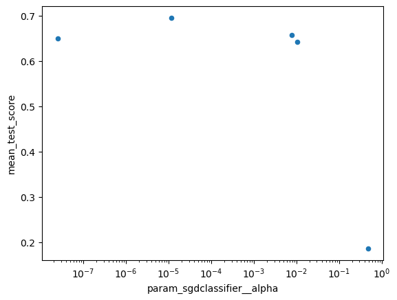

```python
cv_results = pd.DataFrame(search.cv_results_)
cv_results.plot(
    "param_sgdclassifier__alpha", "mean_test_score", kind="scatter", logx=True
)
```

```python
sgd.set_params(countvectorizer__ngram_range=(1, 2), sgdclassifier__alpha=(1e-4))
sgd.fit(train["tokens"], train["wine_variant"])
predicted = sgd.predict(test["tokens"])
print(classification_report(test["wine_variant"], predicted))
```

```
                    precision    recall  f1-score   support

Cabernet Sauvignon       0.70      0.81      0.75      7558
        Chardonnay       0.85      0.83      0.84      4861
            Merlot       0.71      0.35      0.47      1381
        Pinot Noir       0.75      0.88      0.81      9618
          Riesling       0.82      0.77      0.80      2421
   Sauvignon Blanc       0.85      0.66      0.74      1278
             Syrah       0.72      0.55      0.62      3426
         Zinfandel       0.83      0.54      0.65      2082

          accuracy                           0.76     32625
         macro avg       0.78      0.67      0.71     32625
      weighted avg       0.76      0.76      0.75     32625
```

### **Statistical test to show whether SGD is significantly better than the MultiomialNB baseline**

```python
from scipy.stats import binomtest, wilcoxon
```

```python
diff = (sgd_predicted == test["wine_variant"]).astype(int) - (
    mnb_predicted == test["wine_variant"]
).astype(int)
sum(diff == 1), sum(diff == -1), sum(diff == 0)
```

```
(2380, 1786, 28459)
```

```python
binomtest(sum(diff == 1), len(diff), alternative="greater")
```

```
BinomTestResult(k=2380, n=32625, alternative='greater', statistic=0.07295019157088123, pvalue=1.0)
```

**The p-value is very high (1.0), which means that the observed number of successes is not significantly different from what would be expected under the null hypothesis. Therefore, the null hypothesis cannot be rejected at a conventional level of significance.**

```python
wilcoxon(diff, alternative="greater")
```

```
WilcoxonResult(statistic=4958730.0, pvalue=1.741360788868698e-20)
```

## **Part-2**

## **LIME**

**In text analysis, LIME can be used to explain why a certain text classification model is making certain predictions. can be used to understand which words or phrases in a text are most responsible for a particular classification result.**

```python
import matplotlib.pyplot as plt
from lime.lime_text import LimeTextExplainer
```

```python
predicted = sgd.predict(test["review_text"])
```

```python
def boundary(X):
    t = sgd.decision_function(X)
    return np.vstack([t, -t]).T
```

```python
explainer = LimeTextExplainer()
```

```python
test["wine_variant"].iloc[1], predicted[1]
```

```
('Syrah', 'Pinot Noir')
```

**Here wine variant sample actually is Syrah but predicted as Pinot Noir**

```python
exp = explainer.explain_instance(test["review_text"].iloc[1], sgd.decision_function, labels=(3,))
```

```python
labels = sgd.named_steps["sgdclassifier"].classes_
labels
```

```
array(['Cabernet Sauvignon', 'Chardonnay', 'Merlot', 'Pinot Noir',
       'Riesling', 'Sauvignon Blanc', 'Syrah', 'Zinfandel'], dtype='<U18')
```

```
[]
```

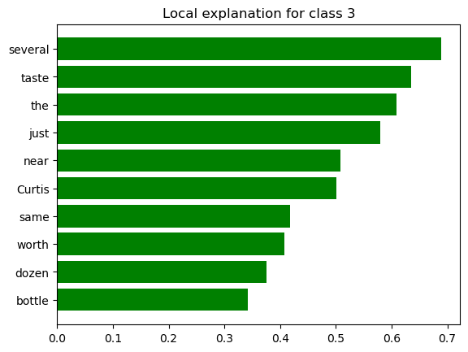

```python
exp.as_pyplot_figure(3)
plt.plot()
```

**All the above words like several, taste, just,curtis,worth, dozen, bottle are used by the model to predict sample 1 as class 3 which is Pinot Noir**

```python
test.iloc[0]["review_text"]
```

```
"hmmm. i have mixed emotions about this wine. on the one hand, i like it's minerality, but on the other, i think the acid is a bit whacked. on the one hand, it's a nice combo of fruit, but it has a funky finish. in the end, i wouldn't purchase it again."
```

```python
test["wine_variant"].iloc[30], predicted[30]
```

```
('Zinfandel', 'Riesling')
```

```python
exp = explainer.explain_instance(test["review_text"].iloc[30], sgd.decision_function, labels=(4,))
```

```
[]
```

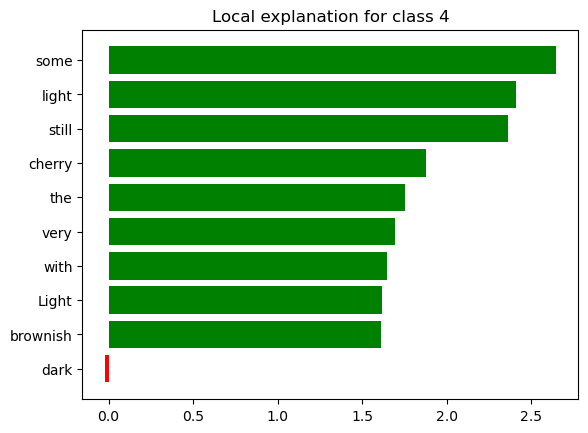

```python
exp.as_pyplot_figure(4)
plt.plot()
```

**All the above words like-cherry,light , brownish, light, still,some make the sample 30 to be predicted as riesling**

**The model is most sensitive to Pinot Noir**

**There is a no overfitting as the model performs well on test data too**

## **Part-3**

## **Decision function**

```python
from sklearn.metrics import classification_report, f1_score
```

```python
labels = sgd.named_steps["sgdclassifier"].classes_# gives labels
scores = sgd.decision_function(test["review_text"]) # returns a score for each sample that indicates how strongly the
#sample is predicted to belong to each class

predicted = sgd.predict(test["review_text"])
```

```python
labels
```

```
array(['Cabernet Sauvignon', 'Chardonnay', 'Merlot', 'Pinot Noir',
       'Riesling', 'Sauvignon Blanc', 'Syrah', 'Zinfandel'], dtype='<U18')
```

```python
scores
```

```
array([[ -4.19226206,  -5.54215571,  -0.72338353, ...,  -4.65060224,
          0.83061601,  -3.1708312 ],
       [ -3.25026256,  -6.27369329,  -1.39888676, ...,  -1.62536696,
         -0.25782302,  -2.40887023],
       [ -5.12858687,  -6.65669726,  -2.0430522 , ...,  -2.89454342,
          0.17946773,  -4.34400921],
       ...,
       [ -3.139606  ,  -3.929709  ,  -1.8027959 , ...,  -2.33107284,
          0.09647825,  -1.1308722 ],
       [ -7.72192285, -11.50935755,  -1.36754898, ...,  -2.81795519,
          2.31165913,  -7.15399227],
       [ -7.48074828, -10.24927449,  -0.86614453, ...,  -3.0422493 ,
          2.05311497,  -4.86407781]])
```

```python
a = np.exp(scores[0,])
a/np.sum(a)
```

```
array([6.90173568e-05, 1.78939805e-05, 2.21550700e-03, 3.82800091e-01,
       6.04182049e-01, 4.36419066e-05, 1.04801272e-02, 1.91672633e-04])
```

```python
scores[0][2]
```

```
-0.7233835348806739
```

```python
scores.max(axis=1) - scores.min(axis=1)
```

```
array([10.42716646, 11.02921313, 14.76265246, ...,  8.20513596,
       26.5409078 , 22.06599403])
```

```python
test["wine_variant"].iloc[0], predicted[0]# politivs, poli
```

```
('Chardonnay', 'Riesling')
```

```python
test["review_text"].iloc[0]
```

```
"hmmm. i have mixed emotions about this wine. on the one hand, i like it's minerality, but on the other, i think the acid is a bit whacked. on the one hand, it's a nice combo of fruit, but it has a funky finish. in the end, i wouldn't purchase it again."
```

```python
scores.max(axis=0)
```

```
array([ 1.82007813e+00,  1.18642951e-01,  7.92236133e+00,  1.45994757e+02,
        1.57430475e+02,  1.12523977e+01,  4.51406175e+01, -2.76185814e-01])
```

```python
scores.argmax(axis=0) # returns index
```

```
array([22356, 19996, 12746, 12746, 12746, 22171, 12746, 21131])
```

```python
test["review_text"].iloc[12746]
```

```
'Decanted 3hrs. The color on this seems like its dark red/purple when looking down on it, but when I sought its underside beneath a bright light bulb, behold I found bright bright crimson there - like a ruby gem; it\'s interesting how you can see all the minuscule particles floating around that way.…
```

**As the review text is very large. It is possible to have maximum scores for this review text**

```python
scores.min(axis=0), scores.argmin(axis=0)
```

```
(array([ -95.44420778, -109.27495069,   -7.55501923,   -1.24564107,
          -1.98925293,  -10.87613161,   -4.47113536,  -58.99555922]),
 array([12746, 12746, 23463, 21607,  7251,  3229, 21706, 12746]))
```

```python
test["review_text"].iloc[11101]
```

```
'The nose on this truly electric purple to black colored wine is exploding with youth, which in comparison to the other wines in the vertical, was clearly more youthful, with leafy tobacco, rich chocolate, cedar, vanilla, black cherry, blackberry, cassis, graphite, and plum. The mouth on this medium…
```

```python
margin = np.abs(scores)
```

```python
margin = scores.max(axis=1) - scores.min(axis=1)
```

```python
margin
```

```
array([10.42716646, 11.02921313, 14.76265246, ...,  8.20513596,
       26.5409078 , 22.06599403])
```

```python
margin.max(axis=0), margin.min(axis=0)
```

```
(266.7054256534926, 1.0075134774108165)
```

```python
# setting scores to absolute value
```

```python
print(classification_report(test["wine_variant"][margin > 70], predicted[margin > 70]))# articles with margin >2
```

```
                    precision    recall  f1-score   support

Cabernet Sauvignon       0.00      0.00      0.00        23
        Chardonnay       0.00      0.00      0.00        23
            Merlot       0.00      0.00      0.00         7
        Pinot Noir       0.33      0.11      0.17        61
          Riesling       0.12      1.00      0.22        17
             Syrah       0.00      0.00      0.00        22
         Zinfandel       0.00      0.00      0.00         7

          accuracy                           0.15       160
         macro avg       0.07      0.16      0.06       160
      weighted avg       0.14      0.15      0.09       160
```

```python
print(classification_report(test["wine_variant"][margin < 5], predicted[margin < 5]))
```

```
                    precision    recall  f1-score   support

Cabernet Sauvignon       0.00      0.00      0.00       210
        Chardonnay       0.00      0.00      0.00       138
            Merlot       0.00      0.00      0.00        38
        Pinot Noir       0.23      0.68      0.34       179
          Riesling       0.06      0.25      0.09        40
   Sauvignon Blanc       0.00      0.00      0.00        39
             Syrah       0.09      0.12      0.11        67
         Zinfandel       0.00      0.00      0.00        75

          accuracy                           0.18       786
         macro avg       0.05      0.13      0.07       786
      weighted avg       0.06      0.18      0.09       786
```

```python
import matplotlib.pyplot as plt
```

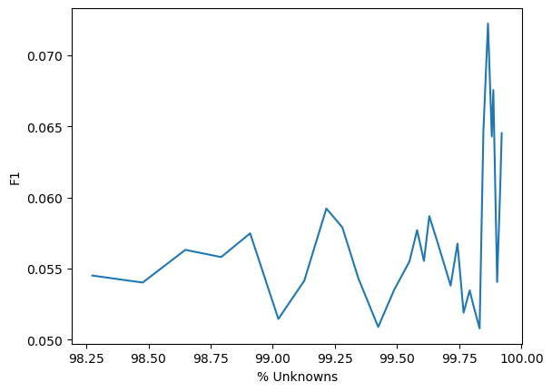

```python
thresh = np.linspace(50, 100, 30)#Creates an array of 50 evenly spaced numbers between -2 and 3,
x = [100 * (1 - sum(margin > t) / len(margin)) for t in thresh]
#% of correctly classified samples (accuracy) for each threshold value t
y = [f1_score(test["wine_variant"][margin > t], predicted[margin > t], average='macro') for t in thresh]

plt.plot(x, y)
plt.xlabel("% Unknowns")
plt.ylabel("F1")
#
```

## **Part-4**

```
<sklearn.metrics._plot.confusion_matrix.ConfusionMatrixDisplay at 0x2b89299163e0>
```

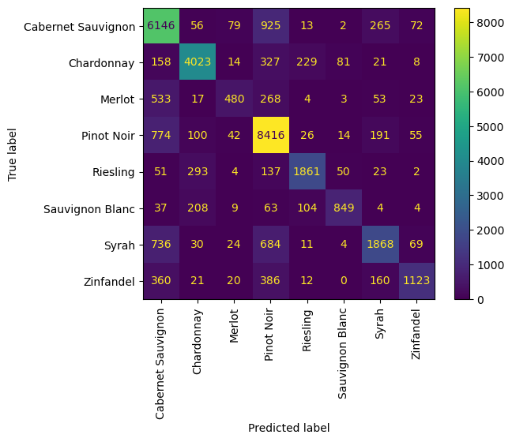

```python
ConfusionMatrixDisplay.from_estimator(
    sgd, test["tokens"], test["wine_variant"], xticks_rotation=90
)
```

**The model is good at predicting Pinot Noir as, there is more Pinot Noir train samples**